# STAT/CSSS 564: Assignment 4

Miranda Petty

May 14, 2017

## Instructions

1. Fork this repository to your account
2. Edit the file `solutions.Rmd` with your solutions to the problems.
3. Submit a pull request to have it graded. Include an up-to-date knitted HTML or PDF file.

For updates and questions follow the Slack channel: [#assignment4](https://uwcsss564.slack.com/messages/C5DBV8266).

This assignment will require the following R packages:

## Problem 1 Replicating Fearon

```r
  library("rstan")
  library("rstanarm")
  library("foreign")
  library("tidyverse")
  library("loo")
```

Set these for fast sampling

```r
  rstan_options(auto_write = TRUE)
  options(mc.cores = parallel::detectCores())
```

@FearonLaitin2003 is a famous paper in the civil war (intra-state) war literature. It analyzes the factors associated with the onset of civil war

@MontgomeryNyhan2010a replicate this work using Bayesian Model Averaging. We will replicate it using regularization methods. Replication data is [here](http://www.dartmouth.edu/~nyhan/montgomery-nyhan-replication.zip).

```r
  wars <- read.dta('data/nwarsl.dta')
  other <- read.dta('data/fl.dta')
  df <- inner_join(wars, other, by = c('ccode', 'year'))
  df <- df[df$onset != 4,]  # coding error
  df$loglang <- log(df$numlang)
  keepvars <- "onset warl gdpenl lpopl1 lmtnest ncontig Oil nwstate instab polity2l ethfrac relfrac anocl deml nwarsl plural plurrel muslim loglang colfra eeurop lamerica ssafrica asia nafrme second"
  keepvars <- strsplit(keepvars, split = " ")[[1]]
  df <- df[,keepvars]
```

Estimate the two models that BMA uses in the paper (with weakly informative priors), and calculate the LOO performance of these methods. When replicating results from papers, you will often have to dig through some confusing code or files, perhaps in programming languages or file formats you’re unfamiliar with (we had to do this to write this question!). The two logit models are the first and third used by Fearon and Laitin, and they are specified in the `f&l-rep.do` file in the reference-code directory, which is a Stata file. It shouldn’t be too hard to figure out the model specification from this file, but Slack message one of us if you need a hint.

$$\begin{aligned}[t]
\beta_0 &\sim N(0, 5) \\
\beta_k &\sim N(0, 2.5) & \text{for $k \in 1, \dots, K$.}
\end{aligned}$$

```r
#I pulled the following models from the f&l-rep.do file
mod <- stan_glm(onset ~ warl + gdpenl + lpopl1 + lmtnest + ncontig + Oil + nwstate + instab + polity2l + ethfrac + relfrac, family = binomial(), data = df, prior = normal(0,5))
loo_mod <- loo(mod)
mod2 <- stan_glm(onset ~ warl + gdpenl + lpopl1 + lmtnest + ncontig + Oil + nwstate + instab + ethfrac + relfrac + anocl + deml, family = binomial(), data = df, prior = normal(0,2.5))
loo_mod2 <- loo(mod2)
compare(loo_mod, loo_mod2)
```

```
## elpd_diff        se
##       0.5       2.3
```

## Problem 2 Regularization Priors

Now estimate this model with all 25 predictor variables and the following priors

1. Weakly informative (as above)
2. Hierarchical Shrinkage (df = 3)

```r
mod3 <- stan_glm(onset ~ warl + gdpenl + lpopl1 + lmtnest + ncontig + Oil + nwstate + instab + polity2l + ethfrac + relfrac + anocl + deml + nwarsl + plural + plurrel + muslim + loglang + colfra + eeurop + lamerica + ssafrica + asia + nafrme + second, family = binomial(), data = df)
loo_mod1 <- loo(mod3)
#the hierarchal model takes a long time to run!

mod4 <- stan_glm(onset ~ warl + gdpenl + lpopl1 + lmtnest + ncontig + Oil + nwstate + instab + polity2l + ethfrac + relfrac + anocl + deml + nwarsl + plural + plurrel + muslim + loglang + colfra + eeurop + lamerica + ssafrica + asia + nafrme + second, family = binomial(), data = df, prior = hs(df = 2, global_scale = 0.02), adapt_delta = 0.6)
loo_mod3 <- loo(mod4)
compare(loo_mod1, loo_mod3)
```

```
## elpd_diff        se
##       1.4       4.0
```

(Don’t do Lasso - since in the Bayesian setting it doesn’t make sense)

- Compare the LOO-PSIS stats for all these models. Which fits the best?

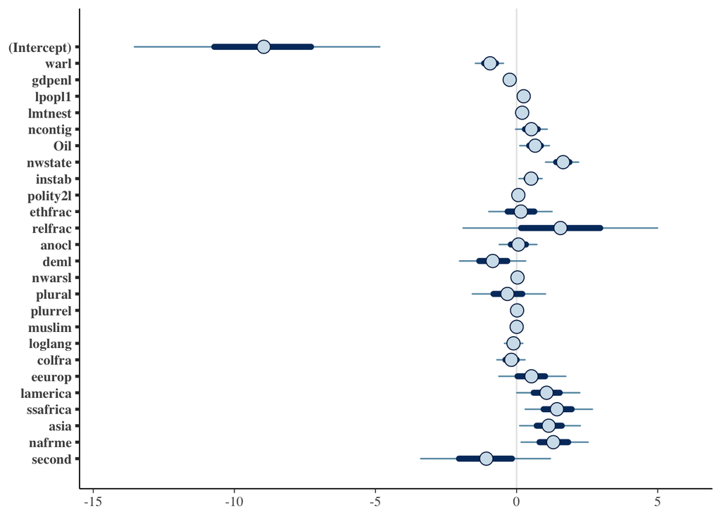

```r
plot(mod3)
```

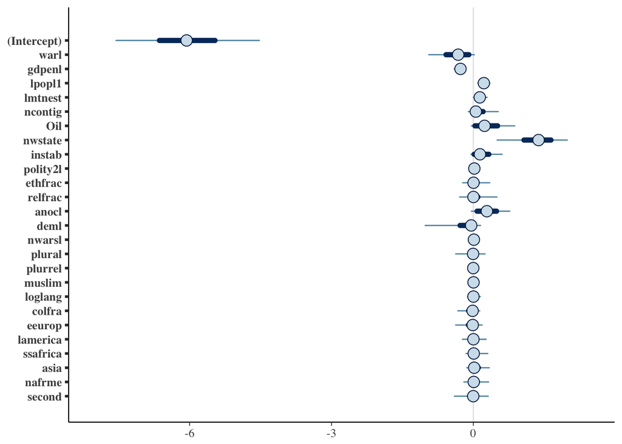

```r
plot(mod4)
```

**How do the coefficients differ between models?** The coefficients for the hierarchal shrinkage prior has less variability in the coefficients, with most coefficients shrunk to 0. The confidence intervals for the coefficients for the second model are also smaller.

## Problem 3

Rerun these models but set autoscale = FALSE.

What does this option do? Which coefficients changed the most? Compare the changes in the coefficients to the standard deviations of these coefficients? Explain how rescaling the variables affects the priors on the coefficients.

```r
m3 <- stan_glm(onset ~ warl + gdpenl + lpopl1 + lmtnest + ncontig + Oil + nwstate + instab + polity2l + ethfrac + relfrac + anocl + deml + nwarsl + plural + plurrel + muslim + loglang + colfra + eeurop + lamerica + ssafrica + asia + nafrme + second, family = binomial(), data = df, prior = normal(autoscale = FALSE, scale = 1))

m3
```

```
## stan_glm(formula = onset ~ warl + gdpenl + lpopl1 + lmtnest +
##     ncontig + Oil + nwstate + instab + polity2l + ethfrac + relfrac +
##     anocl + deml + nwarsl + plural + plurrel + muslim + loglang +
##     colfra + eeurop + lamerica + ssafrica + asia + nafrme + second,
##     family = binomial(), data = df, prior = normal(autoscale = FALSE,
##         scale = 1))
##
## Estimates:
##             Median MAD_SD
## (Intercept) -7.0    1.5
## warl        -0.8    0.3
## gdpenl      -0.3    0.1
## lpopl1       0.3    0.1
## lmtnest      0.2    0.1
## ncontig      0.4    0.3
## Oil          0.7    0.3
## nwstate      1.5    0.3
## instab       0.4    0.2
## polity2l     0.1    0.0
## ethfrac      0.1    0.5
## relfrac      0.3    0.9
## anocl        0.2    0.4
## deml        -0.6    0.6
## nwarsl       0.0    0.1
## plural      -0.1    0.6
## plurrel      0.0    0.0
## muslim       0.0    0.0
## loglang     -0.1    0.2
## colfra      -0.2    0.3
## eeurop       0.0    0.5
## lamerica     0.4    0.5
## ssafrica     0.7    0.5
## asia         0.5    0.4
## nafrme       0.6    0.5
## second      -0.3    0.8
##
## Sample avg. posterior predictive
## distribution of y (X = xbar):
##          Median MAD_SD
## mean_PPD 0.0    0.0
```

## Problem 4 Model Comparison

```r
compare(loo_mod1, loo_mod3)
```

```
## elpd_diff        se
##       1.4       4.0
```

With LOO, when we have small observations, this cross-validation method is not as accurate and a kfold cross-validation method is better. I explain this further below in the third part of my answer for this question.

```r
loo_mod1
```

```
## Computed from 4000 by 6326 log-likelihood matrix
##
##          Estimate   SE
## elpd_loo   -495.8 39.3
## p_loo        26.2  2.6
## looic       991.5 78.7
##
## Pareto k diagnostic values:
##                          Count  Pct
## (-Inf, 0.5]   (good)     6303  99.6%
##  (0.5, 0.7]   (ok)          7   0.1%
##    (0.7, 1]   (bad)         7   0.1%
##    (1, Inf)   (very bad)    9   0.1%
## See help('pareto-k-diagnostic') for details.
```

```r
loo_mod3
```

```
## Computed from 4000 by 6326 log-likelihood matrix
##
##          Estimate   SE
## elpd_loo   -494.4 38.6
## p_loo        16.3  1.6
## looic       988.7 77.3
##
## Pareto k diagnostic values:
##                          Count  Pct
## (-Inf, 0.5]   (good)     6298  99.6%
##  (0.5, 0.7]   (ok)          9   0.1%
##    (0.7, 1]   (bad)        10   0.2%
##    (1, Inf)   (very bad)    9   0.1%
## See help('pareto-k-diagnostic') for details.
```

**Which model fits better?** The model with the hierarchal shrinkage prior fits better.

**The LOO-PSIS approximates Leave-one-Out cross validation. LOO-CV estimates the out-of-sample model fit by fitting the model to n−1 observations and predicting the observation that was not included. Given the structure of the data, is this the out-of-sample quantity of interest? Provide another cross-validation example that may be more appropriate and discuss why. You do not need to implement it.**

Because of our large sample size, the computational time of LOO is much longer than other cross validation methods that we could use. We could instead use a K-fold cross validation where data are split into K number of groups and the model’s predictive ability is tested. K-fold cross validation produces estimates of the prediction error that are less variable.

[figure not shown]

```r
plot(loo_mod3$elpd_loo)
```

## Model Size

**Compare the model sizes given by loo using the results from the previous section. How does that compare to the actual number of parameters in the model?**

For the model with a weakly informative prior, the number of effective parameters (p_loo) is roughly the same as the number of parameters that were in the model. For the hierarchal shrinkage prior, the number of effective parameters is only about 16, which is less than the actual number of parameters in the model.

**The HS prior more aggressively shrinks coefficients towards zero. Is the mean of any coefficient exactly zero?**

```r
mod4
```

```
## stan_glm(formula = onset ~ warl + gdpenl + lpopl1 + lmtnest +
##     ncontig + Oil + nwstate + instab + polity2l + ethfrac + relfrac +
##     anocl + deml + nwarsl + plural + plurrel + muslim + loglang +
##     colfra + eeurop + lamerica + ssafrica + asia + nafrme + second,
##     family = binomial(), data = df, prior = hs(df = 2, global_scale = 0.02),
##     adapt_delta = 0.6)
##
## Estimates:
##             Median MAD_SD
## (Intercept) -6.1    0.9
## warl        -0.3    0.4
## gdpenl      -0.3    0.1
## lpopl1       0.2    0.1
## lmtnest      0.1    0.1
## ncontig      0.1    0.1
## Oil          0.2    0.3
## nwstate      1.4    0.4
## instab       0.1    0.2
## polity2l     0.0    0.0
## ethfrac      0.0    0.1
## relfrac      0.0    0.1
## anocl        0.3    0.3
## deml         0.0    0.1
## nwarsl       0.0    0.0
## plural       0.0    0.1
## plurrel      0.0    0.0
## muslim       0.0    0.0
## loglang      0.0    0.1
## colfra       0.0    0.1
## eeurop       0.0    0.1
## lamerica     0.0    0.1
## ssafrica     0.0    0.1
## asia         0.0    0.1
## nafrme       0.0    0.1
## second       0.0    0.1
##
## Sample avg. posterior predictive
## distribution of y (X = xbar):
##          Median MAD_SD
## mean_PPD 0.0    0.0
```

No. Although the median of some of the coefficients has been shrunk to zero, the mean has not.

**Can you think of a method to define a thresh-hold where coefficients of some variables could be treated as effectively zero? The solutions will provide some examples from the literature (and my Bayesian notes have references to some), but try to think it through on your own. The idea isn’t to get it “right”, but think about the problem prior to finding out how others have approached (and maybe solved?) the problem.** I’m not sure, but maybe coefficients with small variances could be treated effectively as zero.

## Posterior Predictive Checks

Thus far, we’ve only compared models using the log-posterior values. Using a statistic of your choice, assess the fit of data generated from the model to the actual data using posterior predictive checks.

```r
require("bayesplot")
#re-fitting the hierarchal model so that I can get the y values
mod5 <- stan_glm(onset ~ warl + gdpenl + lpopl1 + lmtnest + ncontig + Oil + nwstate + instab + polity2l + ethfrac + relfrac + anocl + deml + nwarsl + plural + plurrel + muslim + loglang + colfra + eeurop + lamerica + ssafrica + asia + nafrme + second, family = binomial(), data = df, y = TRUE, prior = hs(df = 2, global_scale = 0.02), adapt_delta = 0.6)
y<-df$onset
yrep<-mod5$y

#ppc_stat(y, yrep, stat = "mean")
```

I tried to do the posterior predictive check using the above method, but it did not work. I commented it out so that my file will still knit. I will review the solutions and try again.

## Taking Time Seriously

Generally the probbility of war onset is a function of time since the last war. One variable not in the previous models is the time since the last civil war; though it is discussed in a footnote of @Fearon1998a [fn. 26]. @BeckKatzTucker1998a note that a duration model with time-varying covariates can be represented as a binary choice model that includes a function of the time at risk of the event. As such we could rewrite the model
$$\eta_{c,y} = x_{c,y}'\beta + f(d_{c,y})$$
where $d_{i,t}$ is the time since the last civil war or the first observation of that country in the data.

One issue is that we don’t know the duration function, $f$. Since $f$ is unkown, and the analyst generally has few priors about it, generally a flexible funcitonal form is used. @BeckKatzTucker1998a suggest using a cubic spline, while @CarterSignorino2010a suggest a polynomial. In particular, @CarterSignorino2010a suggest a cubic polynomial, meaning the linear predictors now becomes,
$$\eta_{c,y} = x_{c,y}'\beta + \gamma_1 d_{c,y} + \gamma_2 d_{c,y}^2 + \gamma_3 d_{c,y}^3$$

- @CarterSignorino2010 argue that a cubic polynomial is usually sufficient to capture the time-dependence in this sort of data. This is another sort of model choice. How would you solve the choice of the the order of the polynomial with regularization? Include this variable, and re-estimate a model.

```r
mod5<-stan_glm(onset ~ warl + warl^2 + warl^3, family = binomial(), data = df, prior = normal(0,1))
mod5
```

```
## stan_glm(formula = onset ~ warl + warl^2 + warl^3, family = binomial(),
##     data = df, prior = normal(0, 1))
##
## Estimates:
##             Median MAD_SD
## (Intercept) -4.1    0.1
## warl        -0.1    0.3
##
## Sample avg. posterior predictive
## distribution of y (X = xbar):
##          Median MAD_SD
## mean_PPD 0.0    0.0
```

I would create a model that includes an interaction term for all variables with duration, and I would use a hierarchal prior and then use k-fold cross validation to asses the model fit.

## Time Trends and Time-Varying Coefficients